# **Panorama da inflação**

Os principais índices de inflação do Brasil, apontam em setembro de 2007 um avanço da inflação de em média **0.57%**. Com esse resultado, no ano a inflação acumula uma variação média positiva de **3.31%**, e em 12 meses uma variação média acumulada de **4.91%**.

[output not shown]

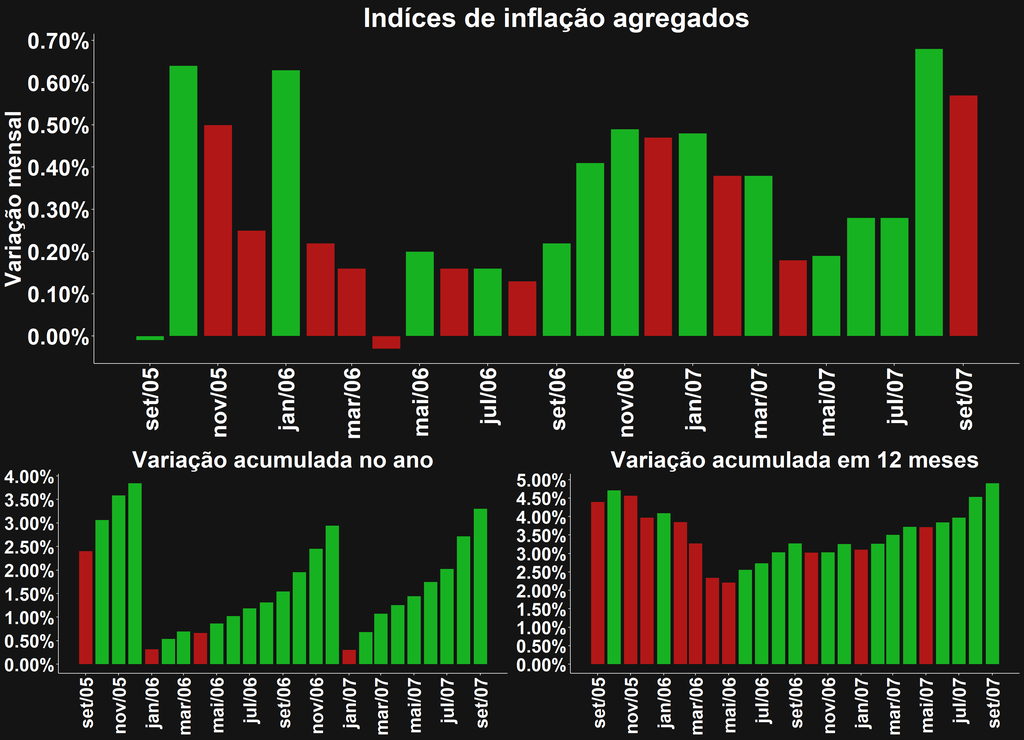

Índices selecionados para a média: IPCA, INPC e IGP-M.

# IPCA

|  | 09/2006 | 08/2007 | 09/2007 |
| --- | --- | --- | --- |
| Variação mensal | 0.21% | 0.47% | 0.18% |
| Variação acumulada no ano | 2% | 2.8% | 2.99% |
| Variação acumulada em 12 meses | 3.7% | 4.18% | 4.15% |

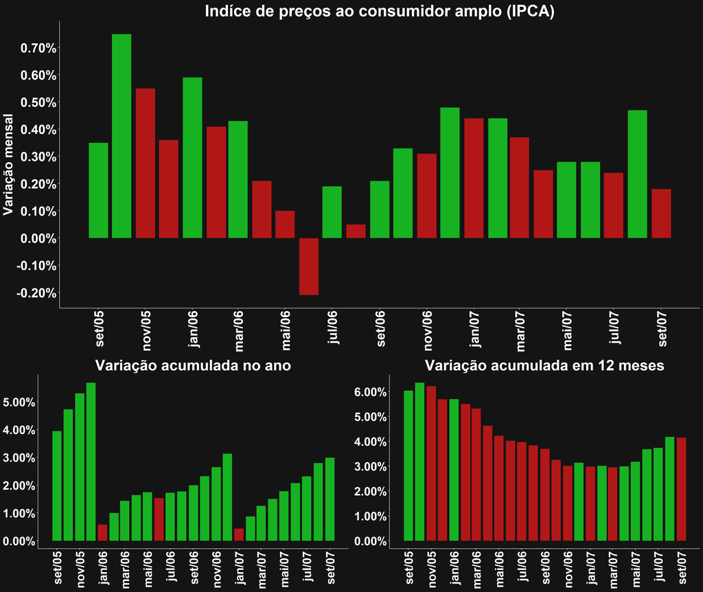

Os grupos que tiveram maior resultado positivo foram Habitação (0.54%) e Vestuário (0.45%), e negativo Comunicação (-0.53%) e Transportes (-0.16%).

|  | Variação mensal | Variação acumulada no ano | Peso mensal |
| --- | --- | --- | --- |
| Alimentação e bebidas | 0.44% | 7.19% | 21.27% |
| Habitação | 0.54% | 1.2% | 13.32% |
| Artigos de residência | 0.17% | -1.7% | 4.51% |
| Vestuário | 0.45% | 1.74% | 6.49% |
| Transportes | -0.16% | 0.86% | 20.47% |
| Saúde e cuidados pessoais | 0.35% | 3.6% | 10.81% |
| Despesas pessoais | 0.14% | 4.5% | 9.68% |
| Educação | -0.11% | 4.06% | 7.14% |
| Comunicação | -0.53% | 0.66% | 6.32% |

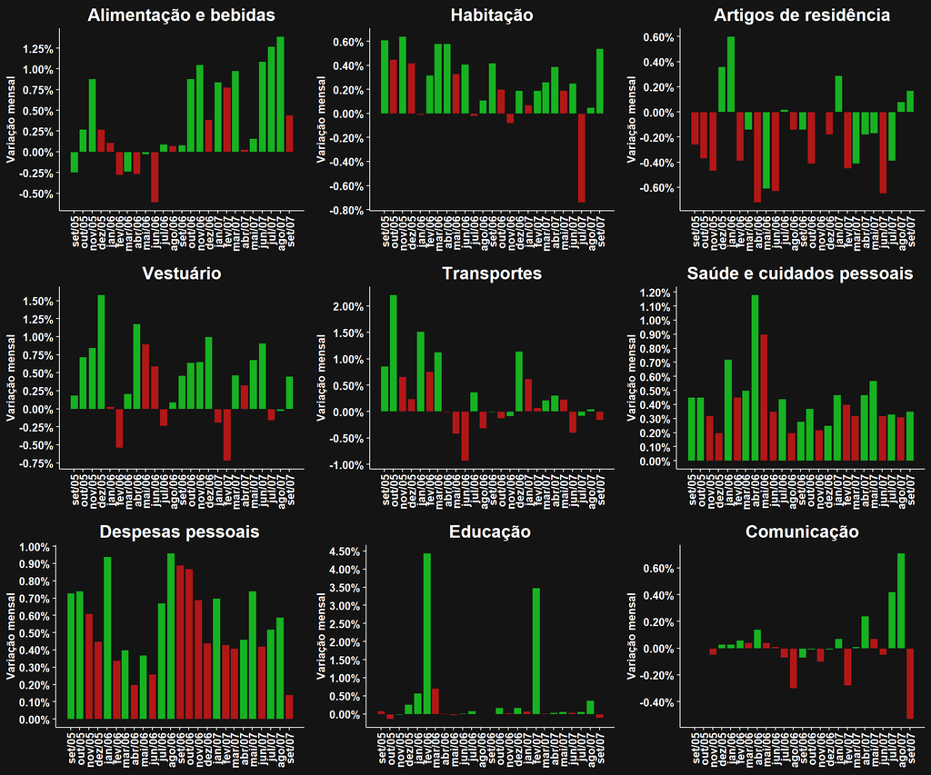

A nível de sub-itens os que mais influenciaram positivamente no resultado em relação ao seu peso foram Refeição (0.66%%) e Leite em pó (8.12%%), e negativamente Leite pasteurizado (-4.86%%) e Telefone fixo (-1.01%%).

|  | Variação mensal | Variação acumulada no ano | Peso mensal |
| --- | --- | --- | --- |
| Leite em pó | 8.12% | 46.88% | 0.3% |
| Taxa de água e esgoto | 1.23% | 4.07% | 1.6% |
| Condomínio | 1.05% | 3.67% | 2.02% |
| Refeição | 0.66% | 5.07% | 3.76% |

|  | Variação mensal | Variação acumulada no ano | Peso mensal |
| --- | --- | --- | --- |
| Gasolina | -0.79% | -2.67% | 4.47% |
| Telefone fixo | -1.01% | 0.21% | 3.64% |
| Seguro voluntário de veículo | -4.01% | -13.17% | 0.41% |
| Leite pasteurizado | -4.86% | 46.49% | 1.36% |

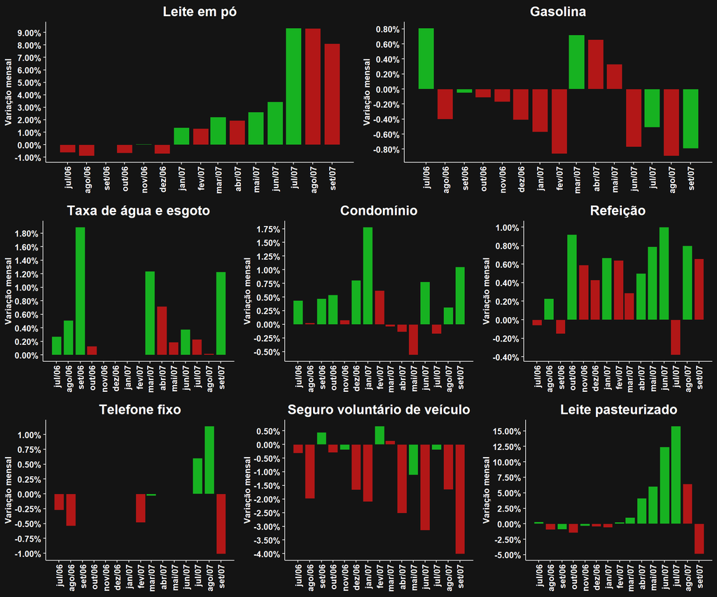

# INPC

O Indíce Nacional de Preços ao Consumidor (INPC) variou 0.25% em setembro, valor superior ao mesmo período do ano anterior quando apresentou uma taxa de 0.16%. Com esse resultado o indíce acumula no ano uma variação positiva de 3.39%, e em 12 meses uma variação positiva de 4.92%.

|  | 09/2006 | 08/2007 | 09/2007 |
| --- | --- | --- | --- |
| Variação mensal | 0.16% | 0.59% | 0.25% |
| Variação acumulada no ano | 1.32% | 3.13% | 3.39% |
| Variação acumulada em 12 meses | 2.86% | 4.82% | 4.92% |

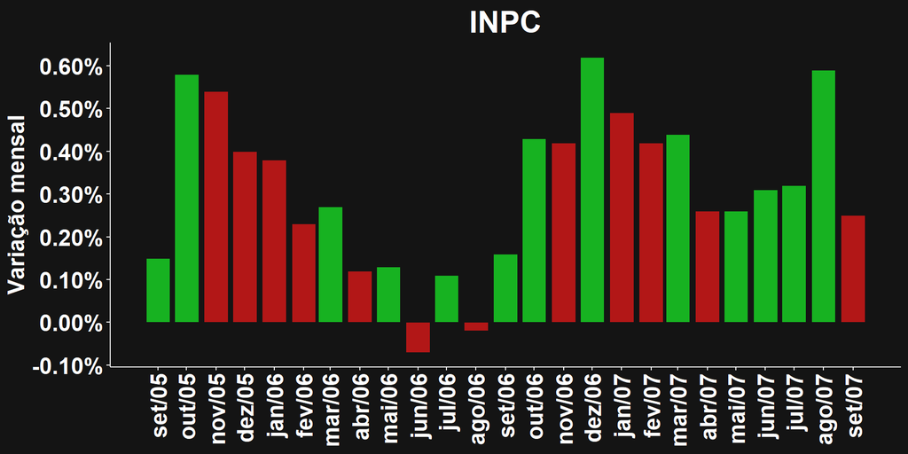

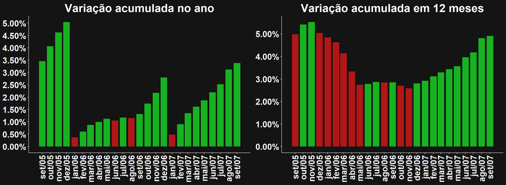

# IGP-M

O Indíce Geral de Preços de Mercado (IGP-M) variou 1.29% em setembro, valor superior ao mesmo período do ano anterior quando apresentou uma taxa de 0.29%. Com esse resultado o indíce acumula no ano uma variação positiva de 3.55%, e em 12 meses uma variação positiva de 5.67%.

|  | 09/2006 | 08/2007 | 09/2007 |
| --- | --- | --- | --- |
| Variação mensal | 0.29% | 0.98% | 1.29% |
| Variação acumulada no ano | 1.32% | 2.23% | 3.55% |
| Variação acumulada em 12 meses | 3.28% | 4.63% | 5.67% |

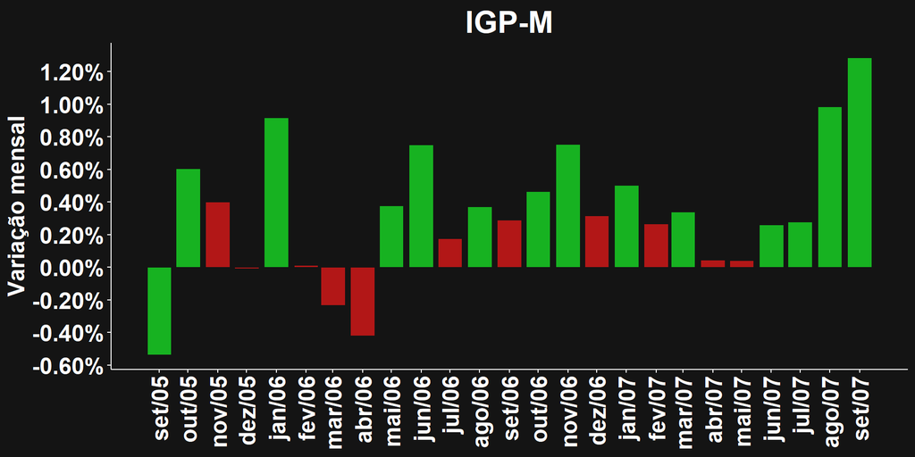

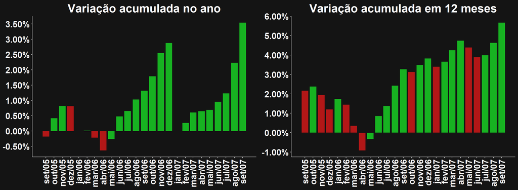

# IGP-DI

O Indíce Geral de Preços - Disponibilidade Interna (IGP-DI) variou 1.17% em setembro, valor superior ao mesmo período do ano anterior quando apresentou uma taxa de 0.24%. Com esse resultado o indíce acumula no ano uma variação positiva de 4%, e em 12 meses uma variação positiva de 6.16%.

|  | 09/2006 | 08/2007 | 09/2007 |
| --- | --- | --- | --- |
| Variação mensal | 0.24% | 1.39% | 1.17% |
| Variação acumulada no ano | 1.38% | 2.8% | 4% |
| Variação acumulada em 12 meses | 3.16% | 5.19% | 6.16% |

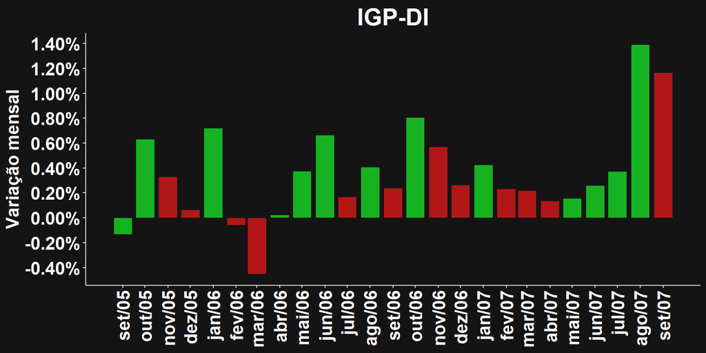

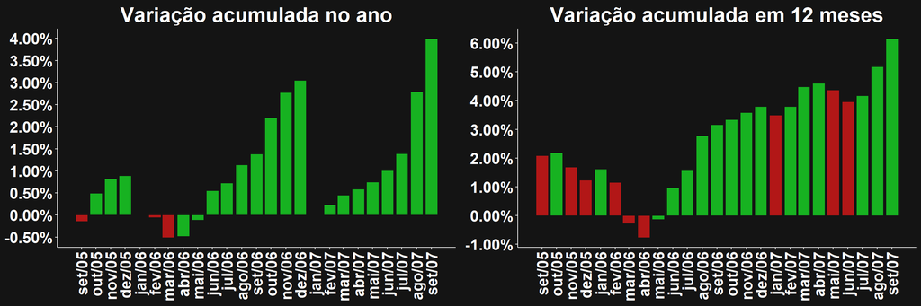

[output not shown]

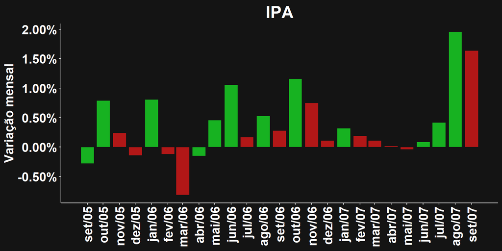

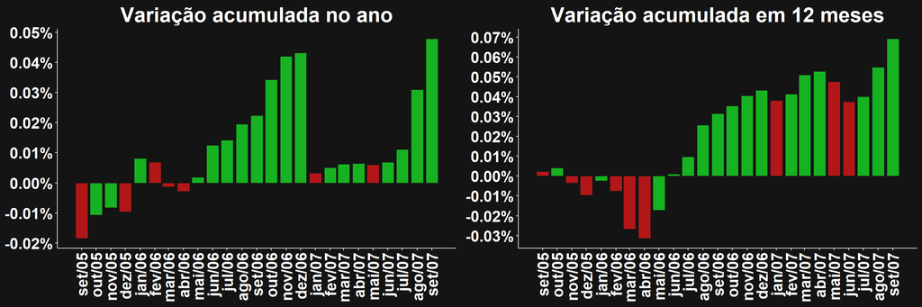

O Indíce de Preços ao Consumidor (IPC), integrante do IGP-DI com peso de 30%, apresentou variação de 0.23% em setembro, valor superior ao mesmo período do ano anterior quando apresentou uma taxa de 0.19%. Com esse resultado o indíce acumula no ano uma variação positiva de 2.76%, e em 12 meses uma variação positiva de 4.5%.

|  | 09/2006 | 08/2007 | 09/2007 |
| --- | --- | --- | --- |
| Variação mensal | 0.19% | 0.42% | 0.23% |
| Variação acumulada no ano | 0.38% | 2.52% | 2.76% |
| Variação acumulada em 12 meses | 2.51% | 4.47% | 4.5% |

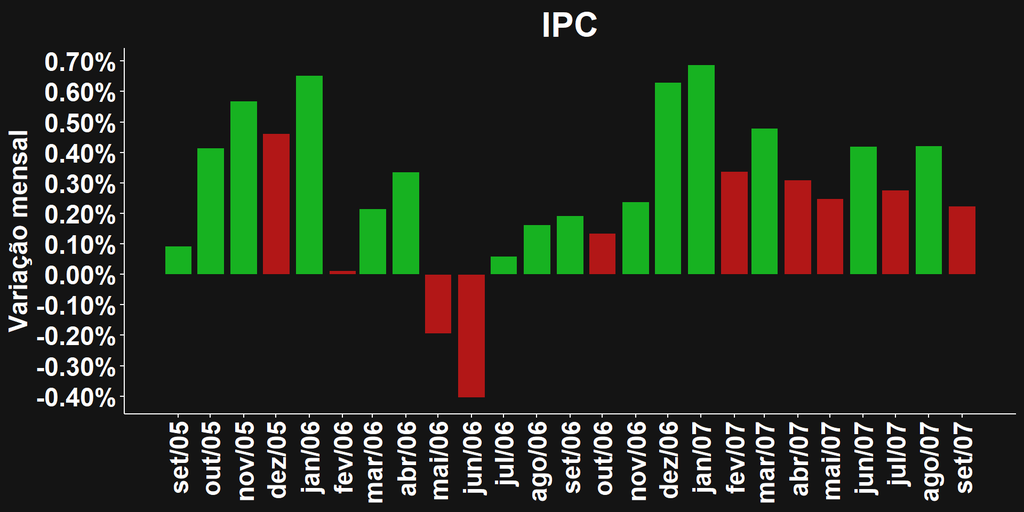

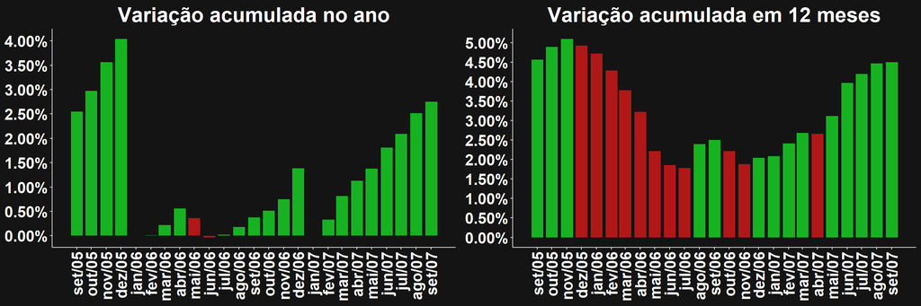

O Indíce Nacional de Custos de Construção (INCC), integrante do IGP-DI com peso de 10%, apresentou variação de 0.51% em setembro, valor superior ao mesmo período do ano anterior quando apresentou uma taxa de 0.11%. Com esse resultado o indíce acumula no ano uma variação positiva de 4.16%, e em 12 meses uma variação positiva de 5.46%.

|  | 09/2006 | 08/2007 | 09/2007 |
| --- | --- | --- | --- |
| Variação mensal | 0.11% | 0.26% | 0.51% |
| Variação acumulada no ano | 3.85% | 3.63% | 4.16% |
| Variação acumulada em 12 meses | 5.09% | 5.05% | 5.46% |

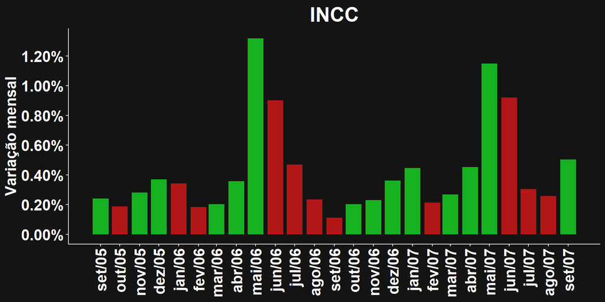

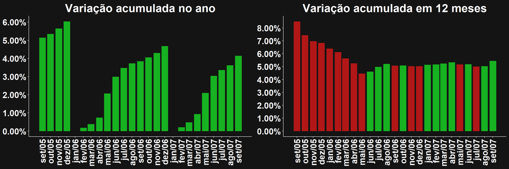

# Estatísticas

As estatísticas descritivas a seguir são feitas com base nos últimos 48 meses, e tem como objetivo possibilitar a avaliação do resultado observado em comparação aos períodos anteriores.

|  | Minimo | 1 Quartil | Mediana | Media | 3 Quartil | Maximo | Desvio Padrão |
| --- | --- | --- | --- | --- | --- | --- | --- |
| IPCA | -0.21% | 0.27% | 0.42% | 0.42% | 0.58% | 0.91% | 0.23% |
| INPC | -0.11% | 0.22% | 0.4% | 0.38% | 0.54% | 0.91% | 0.24% |
| IGP-M | -0.65% | 0.24% | 0.4% | 0.46% | 0.83% | 1.38% | 0.52% |
| IGP-DI | -0.79% | 0.21% | 0.43% | 0.47% | 0.8% | 1.46% | 0.51% |
| IPA | -1.04% | 0.09% | 0.46% | 0.49% | 1.01% | 1.96% | 0.73% |
| IPC | -0.44% | 0.19% | 0.34% | 0.36% | 0.6% | 1.08% | 0.32% |
| INCC | 0.02% | 0.25% | 0.46% | 0.59% | 0.78% | 2.09% | 0.44% |

Levando em consideração o desvio padrão de cada indíce, proporcionalmente os que mais se afastaram da média foram o IGP-M, o IPA e o IGP-DI.

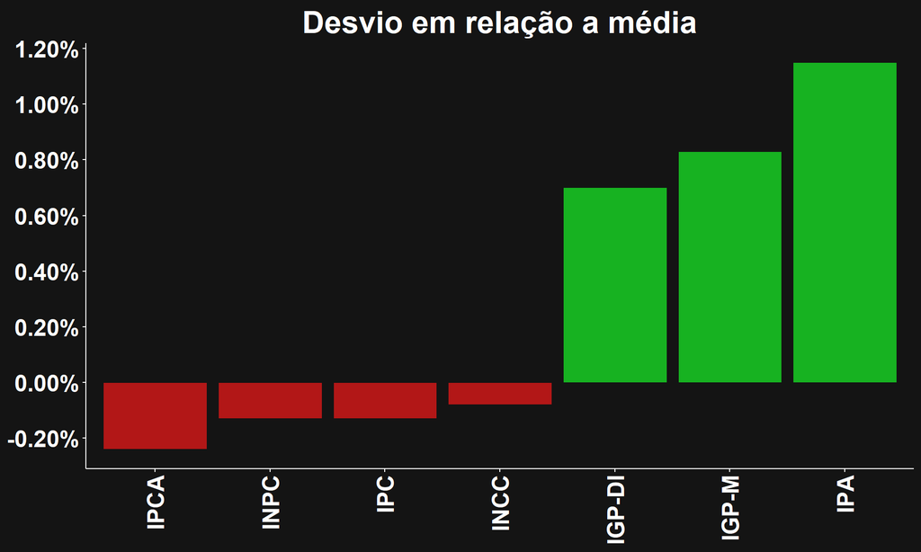

**João Victor Gomes**  
**jvg.santana@gmail.com**  
**[linkedin.com/in/jvictorgomes](https://www.linkedin.com/in/jvictorgomes/)**